# Consolidated Report

Emanuel Muema Dominic

7/12/2017

## Background

Age mixing in sexual relationships refers to how men and women choose their sexual partners with regards to age. Several studies have been conducted to investigate the associations between partner age differences in sexual relationships, sexual risk behaviours, HIV status and HIV acquisition risk. However, the evidence for increased individual level risk is mixed, with some studies showing a positive association between relationship age differences with HIV prevalence, while other studies that have measured HIV incidence have not found any clear association.

The research question we intend to answer is whether there exists an association between age differences in relationships and relationship characteristics—condom use, sex frequency, partner type and relationship duration—that have previously been found to have a potential relationship with HIV risk. Using SHIMS baseline survey data, our objective is to investigate:

1. The relationship between partner age and participant age
2. The relationship between condom use and age differences
3. The relationship between sex frequency and age differences
4. The relationship between partner type and age differences
5. The relationship between relationship duration and age differences

The following are the hypotheses in this study

The average age difference between a participant and their sexual partner(s) does not change with age The average age difference between a participant and their sexual partner(s) changes with age The average age difference between a participant and their sexual partner(s) does not increase with increase in age The average age difference between a participant and their sexual partner(s) increases with increase in age

The variation in age difference between the participant and their sexual partner(s) does not change function of age The variation in age difference between the participant and their sexual partner(s) is a function of age The variation in age difference between the participant and their sexual partner(s) does not increase with increase in age The variation in age difference between the participant and their sexual partner(s) increases with increase in age

The probability of consistent condom use does not change with age difference The probability of consistent condom use changes with age difference The probability of consistent condom use does not decrease with increase in age difference The probability of consistent condom use decreases with increase in age difference

The probability of high sex frequency does not change with age difference The probability of high sex frequency changes with age difference The probability of high sex frequency does not increase with increase in age difference The probability of high sex frequency increases with increase in age difference

The probability of a sexual partner being a casual partner does not change with age difference The probability of a sexual partner being a casual partner changes with age difference The probability a sexual partner being a casual partner does not decrease with increase in age difference The probability a sexual partner being a casual partner decreases with increase in age difference

The length of a sexual relationship does not change with age difference The length of a sexual relationship changes with age difference The length of a sexual relationship does not decrease with increase in age difference The length of a sexual relationship decreases with increase in age difference

## Methods

We used the 5% random subset of the SHIMS baseline survey male data in this analysis. We computed the age of the male participants when they had sexual relationship with the partner for the first time and excluded those male participants whose age was less than 15 years. Each row in the dataset represents a relationship. We had a total of 230 relationships that were reported by the male participants only.

#### Statistical Analysis

Our analysis focused on:

1. relationship between the participant age and the partner’s age
2. four relatonship characteristics that have previously been found to have a potential relationship with HIV risk:
   - condom use (ordinal; with levels “never”,“sometimes”,“always”)
   - sex frequency (ordinal; with levels “1”,“between 2-5”,“between 6-10”,“more than 10”)
   - partner type (ordinal,“husband/wife”,“regular partner”,“casual partner”)
   - relationship duration (continous, months)

Age difference was calculated by subtrating the female partner’s age from the male partner’s age (negative age difference implies that the woman is older than the man). The relationship duration was calculated by getting the difference between the relationship began and when it ended. The relationship that were ongoing and the end date was indicated as the enuration date were denoted with an indicator variable. Those relationships that were ongoing had right-censored relationship durations.

For starters, we wanted to investigate if the age of a participant had an effect on the age of the partner. We constructed a linear mixed effects model with a random effect for each participant.

Using cumulative link mixed models, we created models treating condom use, sex frequency and partner type as outcome variables and the participant unique id as a random effect. To assess the relationship between relationship duration and age difference, we constructed a Cox Proportional Hazard model since the relationship duration in the SHIMS dataset is right censored.

## Results

**Figure 1. Plot of partner age against age of participant.**

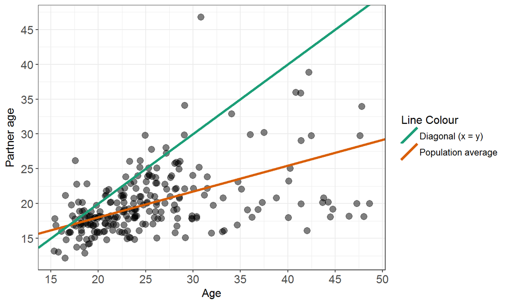

##### Higlights from Figure 1:

- A cone-like shape showing that the variability of the partner age widens as the age of the man increases.
- On average, men tend to choose younger sexual partners generally although the variation in age differences increases with the age of the man.

**Figure 2. Results of cumulative-link mixed model with condom use as the response and age difference as the predictor.** In this model, age difference was a spline term. **a.** Cumulative probability of condom use categories. **b.** Predicted ordinal condom use score (scored as 0 for “never” up to 2 for “always”), with shaded areas representing the 95% confidence interval.

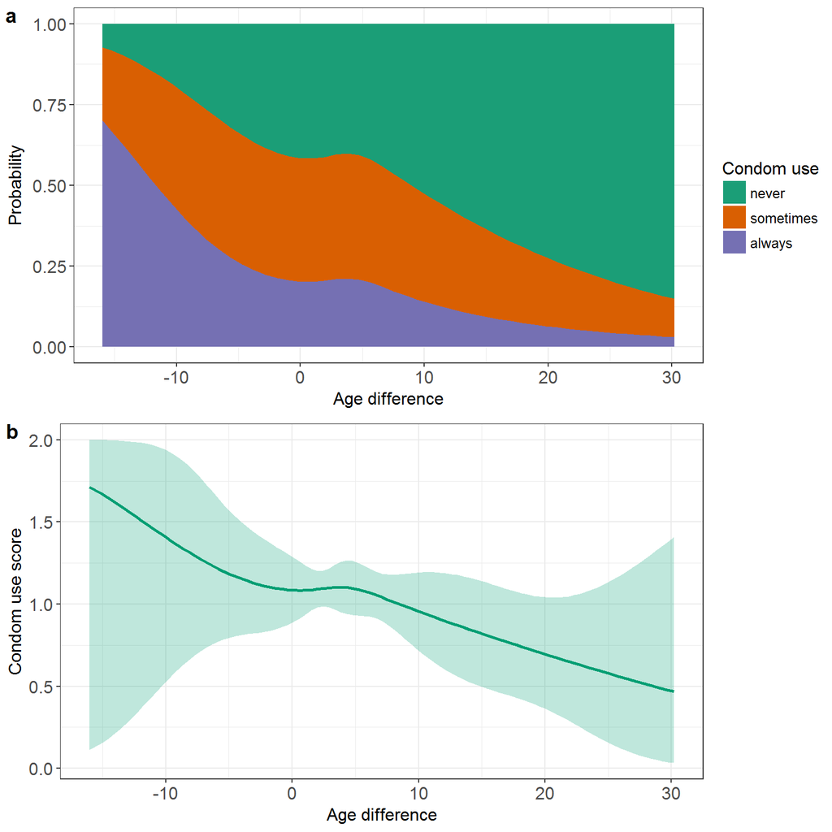

##### Higlights from Figure 2:

- The probability of consistent condom use decreases as the age difference between the man and the partner increases.
- The large peak observed when the age difference is less than -10 is due to lack of enough data.
- The overall condom use decreasing as the age difference increases as shown in Panel (b). Patterns outside the age difference range of -5 years to 20 years cannot be inferred clearly because of the large confidence intervals.

**Figure 3. Results of cumulative-link mixed model with condom use as the response and age difference as the predictor while controlling for age and the number of partners.** In this model, both age difference and age of participant were spline terms. **a.** Cumulative probability of condom use for different age differences. **b.** Cumulative probability of condom use for different age of participants. **c.** Predicted effect of age difference on ordinal condom use score (scored as 0 for “never” up to 2 for “always”), with shaded areas representing the 95% confidence interval. **d.** Predicted effect of age of participant on ordinal condom use score, with shaded areas representing the 95% confidence interval.

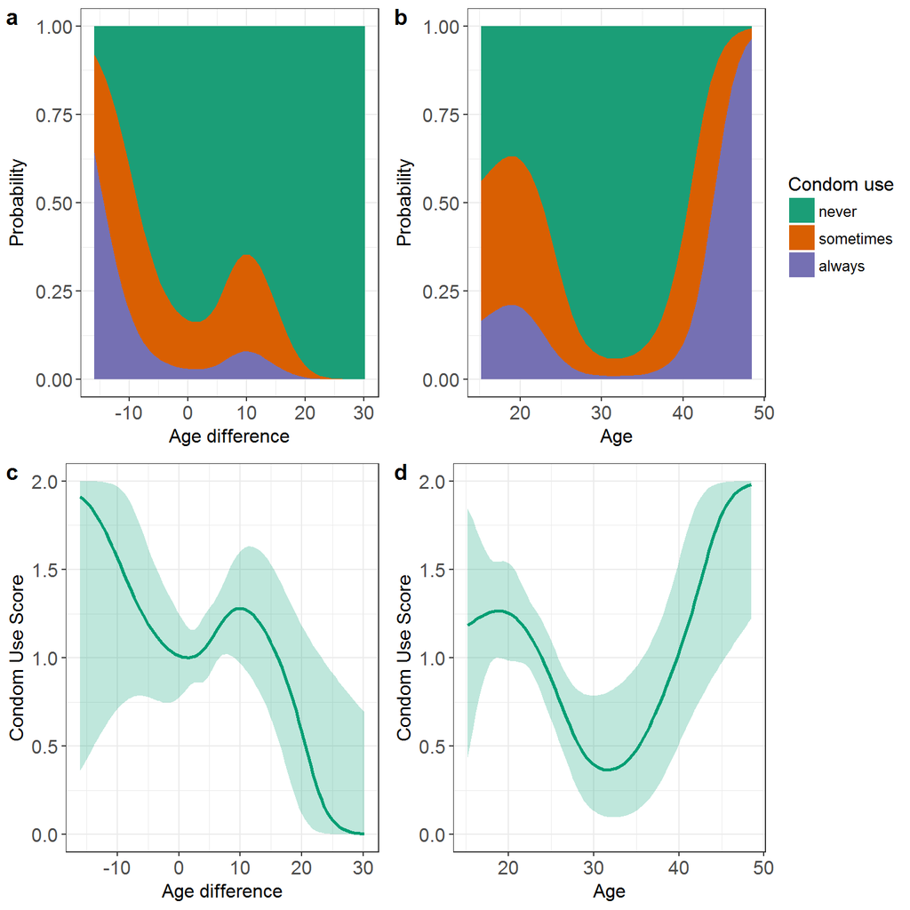

##### Higlights from Figure 3:

- When we account for age as a predictor of condom use, we obseve similar trend like when we had age difference as the only predictor, i.e The probability of always using a condom decreases as the age difference between the man and the partner increases.
- There is a notable peak in the probability of condom use when the age difference is around 10 years.
- Panel (b) shows that the probability of using a condom peaks for men aged around 18 years then drops.
- There is an overall increase in condom use for age differences between 0 and 10 years then it starts decreasing as the age difference greater than 10 years.
- Young people (20–32 years) generally use condoms inconsistently.

**Figure 4. Results of cumulative-link mixed model with sex frequency as the response and age difference as the predictor.** In this model, age difference was a spline term. **a.** Cumulative probability of sex frequency (in the last 6 months) categories. **b.** Predicted effect of age difference on ordinal sex frequency score (scored as 0 for “1 time” up to 3 for “more than 10” times in the last six months), with shaded areas representing the 95% confidence interval.

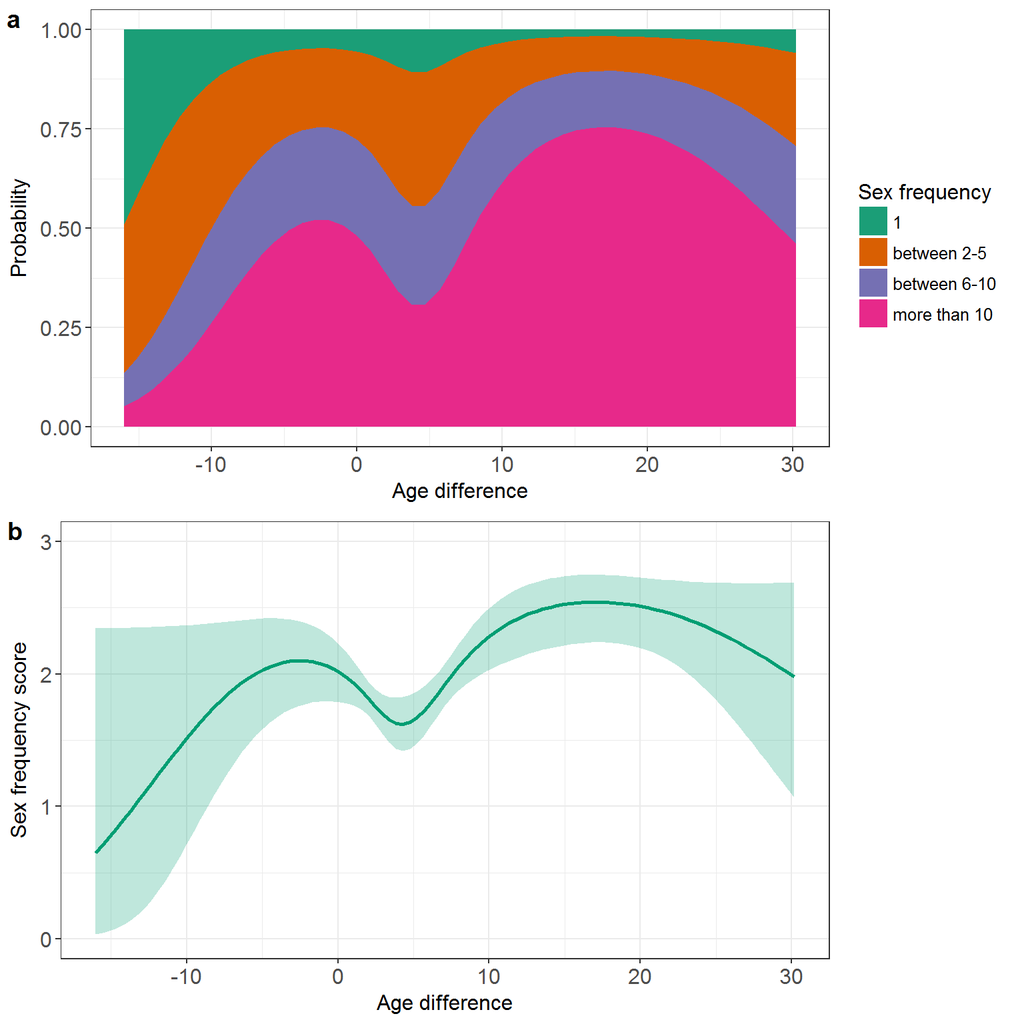

##### Higlights from Figure 4:

- Sex frequency is highest when the man is 2 years younger than the partner and 15 years older than the partner.
- There is a general increase in sex frequency besides the drop observed when the age difference is 4 years.

**Figure 5. Results of cumulative-link mixed model with sex frequency as the response and age difference as the predictor while controlling for age and the number of partners.** In this model, both age difference and age of participant were spline terms. **a.** Cumulative probability of sex frequency (in the last 6 months) for different age differences. **b.** Cumulative probability of sex frequencyfor different age of participants. **c.** Predicted effect of age difference on ordinal sex frequency score (scored as 0 for “1 time” up to 3 for “more than 10” times in the last six months), with shaded areas representing the 95% confidence interval. **d.** Predicted effect of age of participant on ordinal sex frequency score, with shaded areas representing the 95% confidence interval.

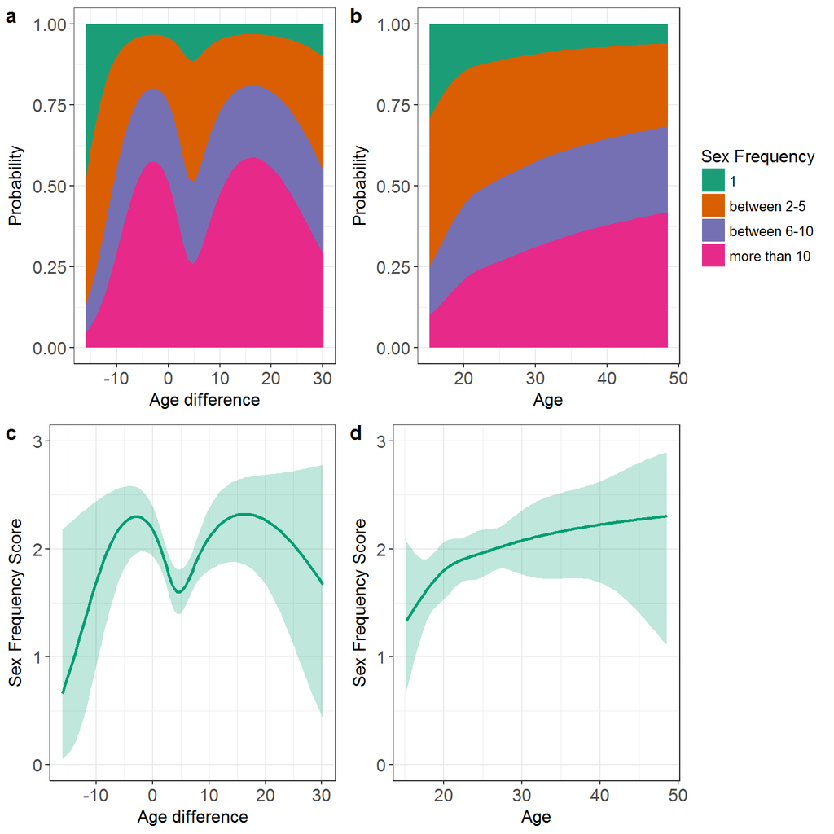

##### Higlights from Figure 5:

- Panel (a) shows a similar trend like in Figure 4a when we had not adjusted for the age and the number of partners.
- There is a non linear increase in sex frequency as the age of the man increases.
- Extreme values of age differences and age have large confidence intervals.

**Figure 6. Results of cumulative-link mixed model with partner type as the response and age difference as the predictor.** In this model, age difference was a spline term. **a.** Cumulative probability of partner type categories. **b.** Predicted effect of age difference on ordinal partner type score (scored as 0 for “husband/wife” up to 2 for “casual partner”), with shaded areas representing the 95% confidence interval.

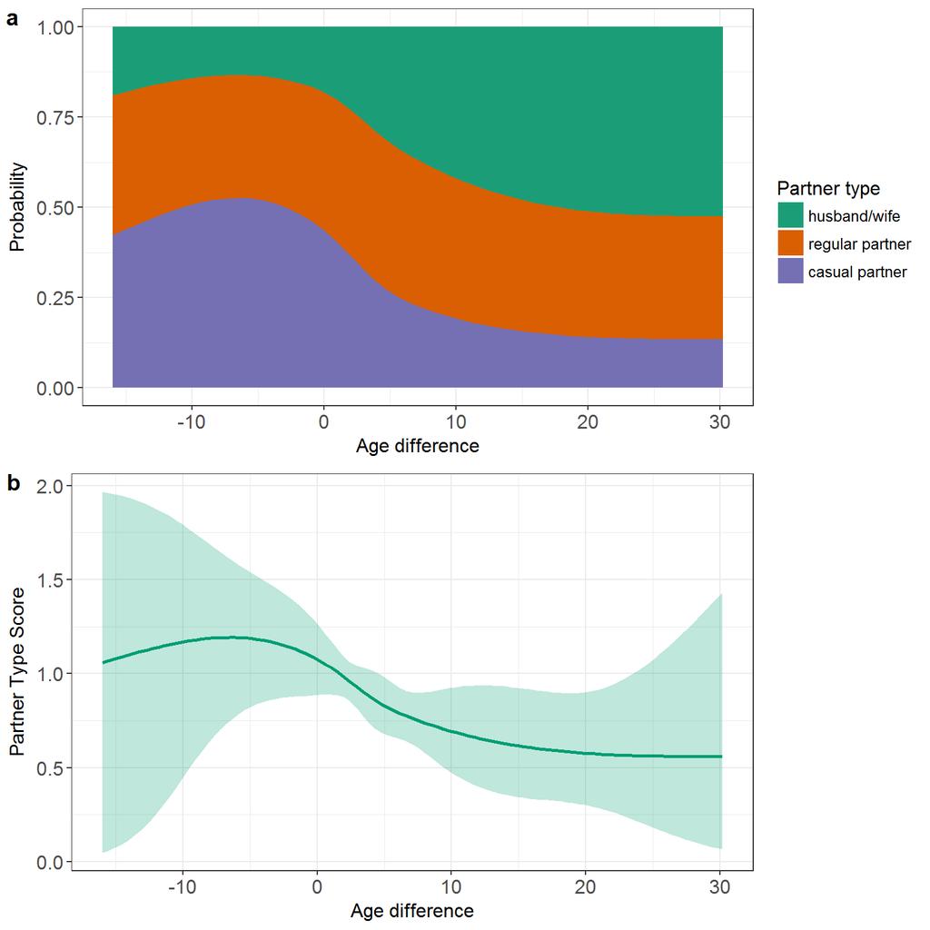

##### Higlights from Figure 6

- The sexaul partner is a casual partner in most of the sexual relationships where the man is younger than the woman.
- There is an increase in probabilty of the partner being a wife as the age difference increases.

**Figure 7. Results of cumulative-link mixed model with partner type as the response and age difference as the predictor while controlling for age and the number of partners.** In this model, both age difference and age of participant were spline terms. **a.** Cumulative probability of partner type for different age differences. **b.** Cumulative probability of partner type for different age of participant. **c.** Predicted effect of age difference on ordinal partner type score (scored as 0 for “husband/wife” up to 2 for “casual partner”), with shaded areas representing the 95% confidence interval. **d.** Predicted effect of age of participant on ordinal partner type score, with shaded areas representing the 95% confidence interval.

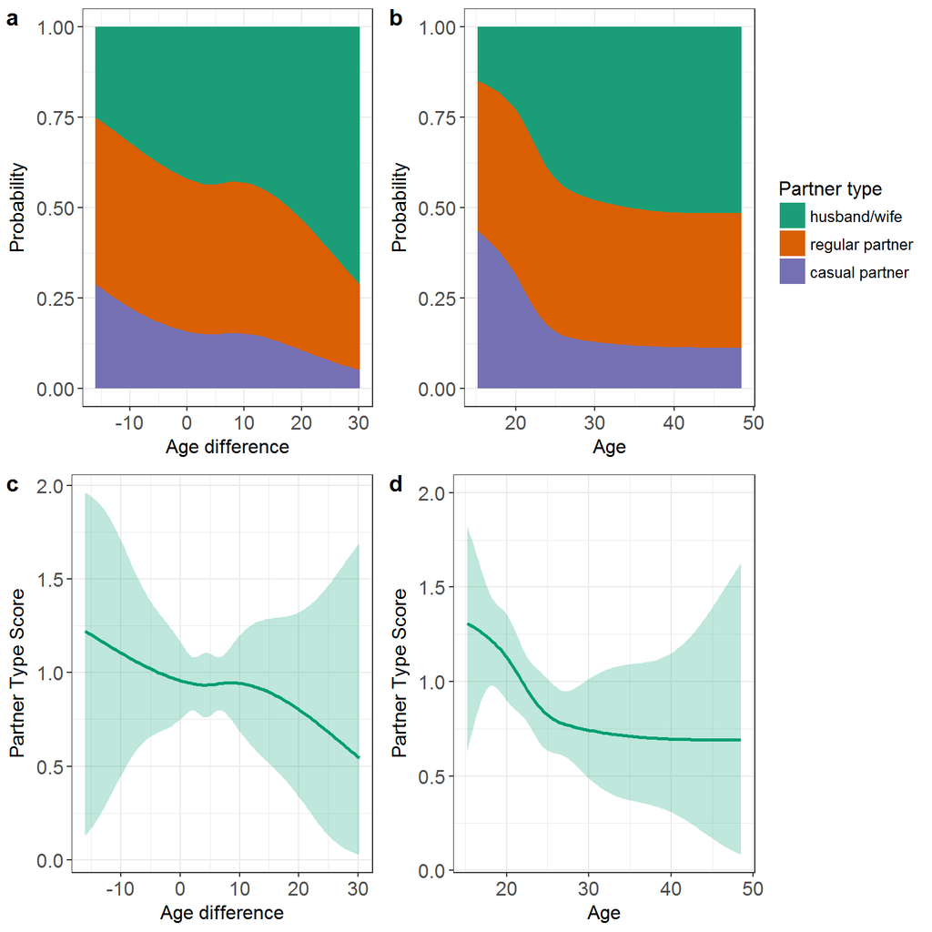

##### Higlights from Figure 7

**Figure 8. Results of Cox Proportional Hazards Model with relationship duration as the response and age difference as the predictor.** In this model, age difference was a spline term. **a.** Predicted HRs for age differences, with mean age difference (6.2 years) as the reference. **b.** Expected survival curves for selected age differences.

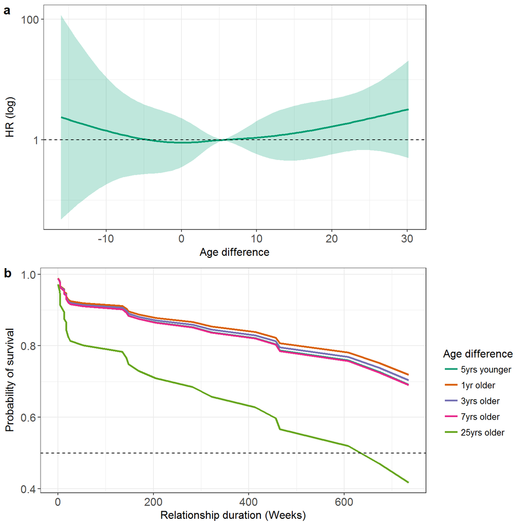

**Figure 9. Results of Cox Proportional Hazards Model with relationship duration as the response and age difference as the predictor while controlling for age and the number of partners.** In this model, both age difference and age of partipant were spline terms. **a.** Predicted HRs for age differences, with mean (age difference = 6.2) as the reference. **b.** Expected survival curves for selected age differences.

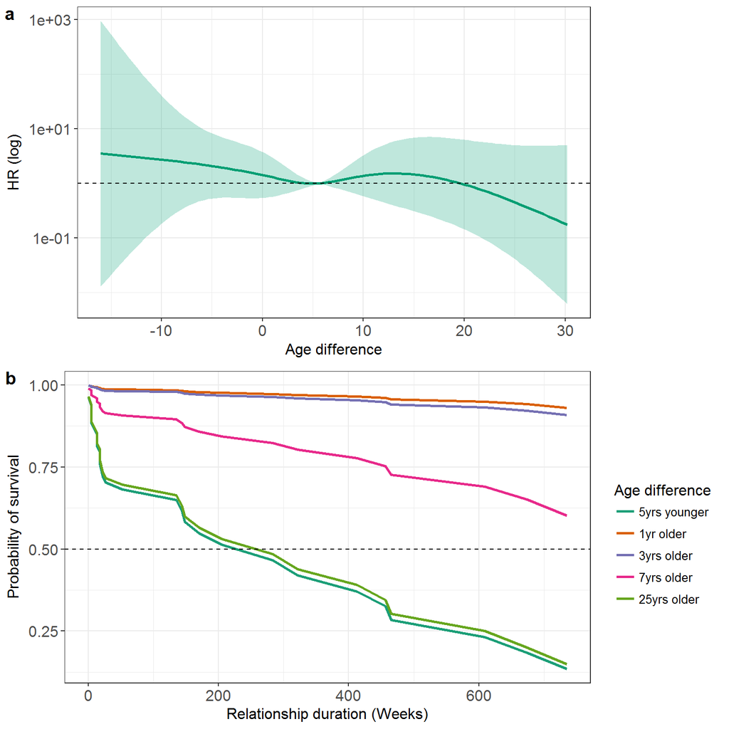

##### Higlights from Figure 9

- The hazard of ending a relationship is greater for relationships where the man is younger than partner and lowest when the age difference is greater than 20 years.
- The relationship durations is shortest when the man is 5 years younger than the partner and when longest when the man is 1 year older than the partner.